# EXT CSCI E-106 Model Data Class Group Project Template

#### Seasonal Trends in Average House Prices

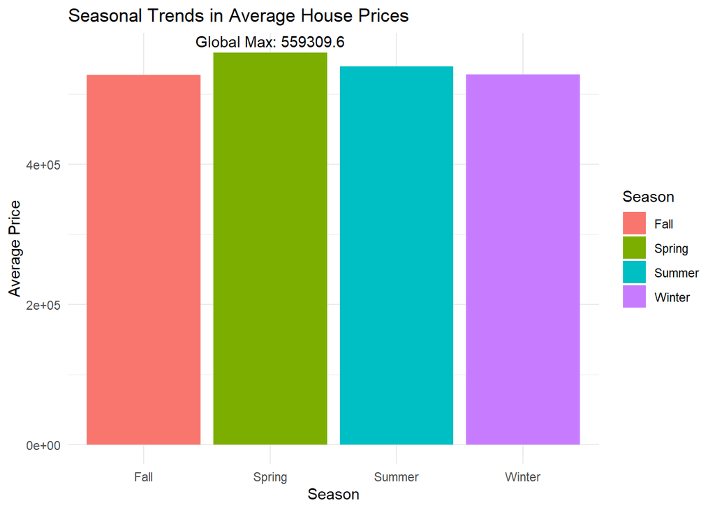

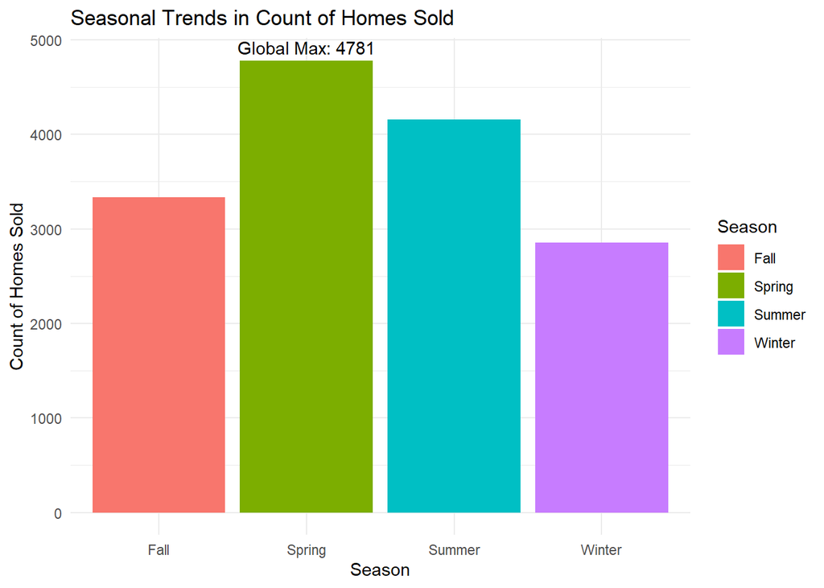

#### Week of the Year Trends in Average House Prices

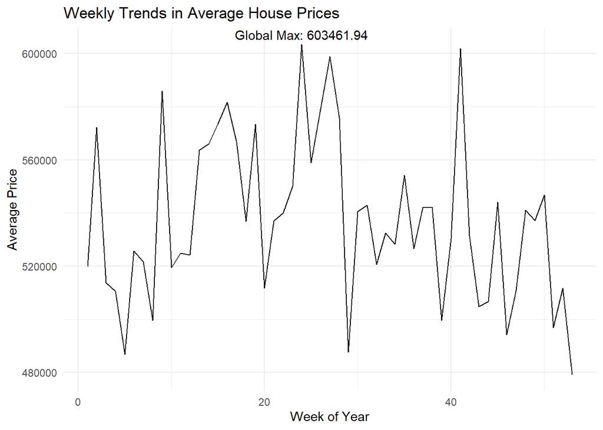

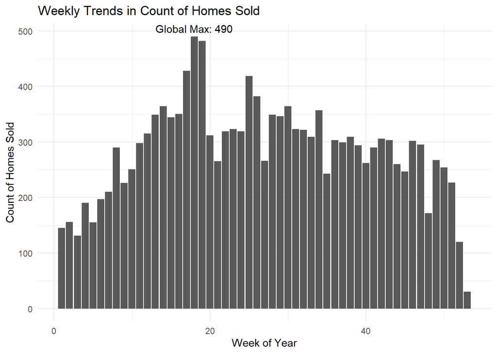

#### Day of the Year Trends in Average House Prices

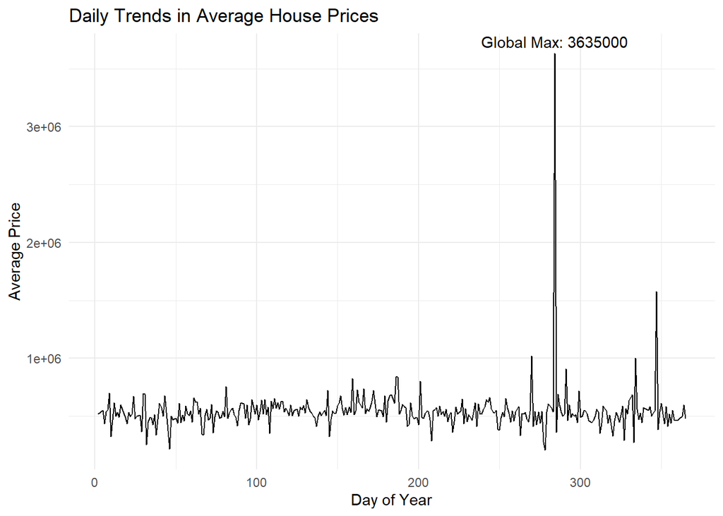

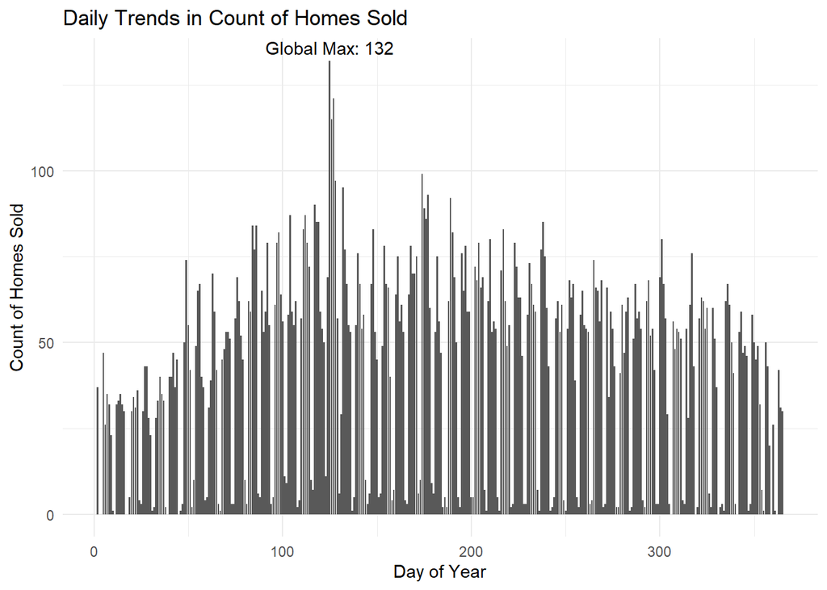

- The “Daily Trends in Average House Prices” line chart showcases the average house prices for each day of the year. It helps identify daily patterns and potential price variations that could be influenced by specific dates or events.

### Geographical Influence Analysis

Investigating the spatial aspect by analyzing the `distance_to_convergence` variable.

[interactive chart not shown]

### Conclusion

This detailed review of the King County house sales dataset underscores the thorough preparation undertaken for the predictive analysis. The dataset’s diverse variables, both continuous and categorical, have been meticulously processed and analyzed, providing a robust foundation for developing the predictive model. With the comprehensive EDA and graphical analysis, we gain valuable insights into the correlations and distributions within the data, setting the stage for effective model building and accurate house price prediction.

## III. Model Development Process

Up to this point, we have successfully conducted an exploratory data analysis (EDA) to gain valuable insights into the dataset. We’ve visualized key features such as price, bedrooms, bathrooms, and more, allowing us to better understand the data’s distribution and relationships. Additionally, we’ve explored various trends, including monthly, seasonal, weekly, and daily trends in both house prices and the count of homes sold. Furthermore, we have cleaned and prepared the data, removing irrelevant variables like `id`, `lat`, and `long` to streamline it for modeling. With these preliminary steps completed, we are now ready to delve into the model development process.

### Initial OLS Model

To commence the model development process, we establish an Ordinary Least Squares (OLS) regression model as our baseline. This initial model utilizes the features that have undergone transformation and cleaning during the exploratory data analysis (EDA) phase. To maintain data quality, enhance model performance, and facilitate interpretability, we begin by removing columns introduced in prior graphical iterations. Additionally, we employ the standard data preprocessing practice of dropping columns with missing values (NA) to ensure dataset integrity. This step ensures that our subsequent analyses and models are built upon a robust and complete dataset, minimizing errors and potential biases.

```r
# Fit a linear regression model to the training data
linear_model_initial <- lm(price ~ ., data = train_df_linear)

# Evaluate OLS_linear
df_results <- evaluate_model("OLS_linear", linear_model_initial, train_df_linear, test_df_linear, target_var = 'price', NULL)

# Conditional logic based on the update_model_parameters flag
if (update_model_parameters) {
  # Run each of the stepwise regression models and update the JSON file
  # Step model both
  model_both <- ols_step_both_p(linear_model_initial, pent=0.35, prem=0.05)
  features_both <- setdiff(names(coef(model_both$model)), "(Intercept)")
  update_model_json("OLS_Step_Both", features_both, json_filepath)

  # Step model Backward
  model_backward <- ols_step_backward_p(linear_model_initial, prem = 0.05)
  features_backward <- setdiff(names(coef(model_backward$model)), "(Intercept)")
  update_model_json("OLS_Step_Backward", features_backward, json_filepath)

  # Step model foward
  model_forward <- ols_step_forward_p(linear_model_initial, penter = 0.05)
  features_forward <- setdiff(names(coef(model_forward$model)), "(Intercept)")
  update_model_json("OLS_Step_Forward", features_forward, json_filepath)
} else {
  # Load model parameters from JSON and build models
  model_params <- fromJSON(json_filepath)

  # Create models based on the loaded features
  if (all(c("OLS_Step_Both", "OLS_Step_Backward", "OLS_Step_Forward") %in% names(model_params))) {
    # For each model type, create the model using the features stored in the JSON
    model_both <- create_model(train_df_linear, 'price', model_params$OLS_Step_Both)
    model_backward <- create_model(train_df_linear, 'price', model_params$OLS_Step_Backward)
    model_forward <- create_model(train_df_linear, 'price', model_params$OLS_Step_Forward)
  } else {
    stop("Required model parameters are missing in the JSON file.")
  }
}

view_model_results(df_results)
```

|  | Model | SSE_train | SSE_test | R_squared_train | R_squared_test | RMSE_train | RMSE_test | MAE_train | MAE_test |
| --- | --- | --- | --- | --- | --- | --- | --- | --- | --- |
| 1 | OLS_linear | 327165657255967.5 | 146321877069309.9 | 0.8401051796677462 | 0.8311833437017644 | 147054.64368827 | 150221.857865984 | 86252.74133100695 | 88389.95997558441 |

```r
# Evaluate OLS_Step_Both
df_results <- evaluate_model("OLS_Step_Both", model_both, train_df_linear, test_df_linear, target_var = 'price', df_results)

# Evaluate OLS_Step_Forward
df_results <- evaluate_model("OLS_Step_Forward", model_forward, train_df_linear, test_df_linear, target_var = 'price', df_results)

# Evaluate OLS_Step_Backward
df_results <- evaluate_model("OLS_Step_Backward", model_backward, train_df_linear, test_df_linear, target_var = 'price', df_results)

view_model_results(df_results)
```

|  | Model | SSE_train | SSE_test | R_squared_train | R_squared_test | RMSE_train | RMSE_test | MAE_train | MAE_test |
| --- | --- | --- | --- | --- | --- | --- | --- | --- | --- |
| 1 | OLS_linear | 327165657255967.5 | 146321877069309.9 | 0.8401051796677462 | 0.8311833437017644 | 147054.64368827 | 150221.857865984 | 86252.74133100695 | 88389.95997558441 |
| 2 | OLS_Step_Both | 331555414936879.9 | 149084367387729.7 | 0.8379597848192202 | 0.8279961622087949 | 148037.9120624784 | 151633.287318145 | 86853.36461300458 | 89153.17247503145 |
| 3 | OLS_Step_Forward | 327303752405197.9 | 146368198875956.8 | 0.840037688784809 | 0.8311299006167764 | 147085.6759650959 | 150245.6342053655 | 86251.38932636962 | 88414.86064389689 |
| 4 | OLS_Step_Backward | 327303752405198.4 | 146368198875957.3 | 0.8400376887848088 | 0.8311299006167758 | 147085.675965096 | 150245.6342053657 | 86251.38932636977 | 88414.86064389719 |

### Next Steps

1. **Multicollinearity Check**: We will calculate the Variance Inflation Factor (VIF) for each predictor to identify multicollinearity, which can inflate the variance of the estimated regression coefficients and make the model less reliable.

Copyright © 2023 Charles and with AI assistance. Fabricated with blood, sweat, and more coffee than a pod of overcaffeinated narwhals. Unauthorized replication of this work will result in a jester performing terribly lame jokes at your next family gathering. Proceed with caution.